# Problem set 1

Eric Helfrich

9/1/19

## Details

- Who did you collaborate with: N/A
- Approximately how much time did you spend on this problem set: 2-3 hours
- What, if anything, gave you the most trouble: Handling the strings for the country names. I originally used the wrong read CSV function.

### Instructions

For this problem set, you’ll have three possible things to do.

- “### Question #” / “xxxxx” = Write your response to each question by replacing the “xxxx. 1-2 sentences is fine.
- “### Code #” = Write R code in the chunk corresponding to the instructions.

For this problem set, there are **15 questions** and **10 code** parts. If you get one wrong, it will be -3 points.

Additional points will be deducted for problems with the formatting as outlined by the problem set 1 instructions (e.g., do not provide .html output, put data into data folder, etc.).

## Task 1

Answer the following questions about RMarkdown from the short lessons.

### Question 1

- What three (3) characters start and end the YAML information for an RMarkdown file?

It can optionally be started and closed with ‘—’.

### Question 2

- What does the code chunk parameter `echo = FALSE` do?

This paramter hides the code from showing and instead just shows the result of the code.

### Question 3

- How do you change the output type for an RMarkdown file?

You change the output format of the render function.

## Task 2: Creating baseline plot

### Code 1

Load the `tidyverse` package.

```r
# make sure you have tidyverse already installed! (hint: install.packages())
library(tidyverse)
```

### Question 4

- What packages are loaded when you call `tidyverse`?

The packages: ggplot2, tibble, tidyr, readr, purr, dplyr, stringr, and forcats are loaded when calling tidyverse

### Code 2

Read in the `corrupt.csv` file and assign it to `corrupt`.

```r
# load in the file 'data/corrupt.csv' and assign it to corrupt
# hint: use the read_csv function from the readr (tidyverse) package
corrupt = read_csv("data/corrupt.csv")
```

### Code 3

Run the `glimpse()` function on the data to explore the column formats.

```r
# run the glimpse() function
glimpse(corrupt)
```

```
## Observations: 704
## Variables: 5
## $ country <chr> "Denmark", "New Zealand", "Finland", "Sweden", "Switzerl…
## $ region  <chr> "Europe and Central Asia", "Asia Pacific", "Europe and C…
## $ year    <dbl> 2015, 2015, 2015, 2015, 2015, 2015, 2015, 2015, 2015, 20…
## $ cpi     <dbl> 91, 91, 90, 89, 86, 88, 85, 84, 83, 81, 85, 81, 79, 79, …
## $ hdi     <dbl> 0.925, 0.915, 0.895, 0.913, 0.939, 0.949, 0.925, 0.924, …
```

### Question 5

- How many rows (observations) and columns (variables) does the data frame include?

The data has 704 rows and 5 columns.

However, it’s not clear if there are duplicated records by year (i.e., this is panel data (record and time oriented)).

### Code 4

Run the `count()` function on `corrupt` and use `year` as the 2nd parameter. This will count how many records by each unique category in `year` (that is, each year)

```r
count(corrupt, year)
```

```
## # A tibble: 4 x 2
##    year     n
##   <dbl> <int>
## 1  2012   176
## 2  2013   176
## 3  2014   176
## 4  2015   176
```

### Question 6

- How many different years does the dataset include?

The dataset includes 4 years

For simplicity, let’s only keep 2015 records.

```r
# uncomment out the lines below

corrupt <- corrupt %>%
   filter(year == 2015) %>%
   na.omit()
```

Let’s revise our existing `region` field. This will help us later on.

```r
# uncomment out the lines below

corrupt <- corrupt %>%
  mutate(region = case_when(
    region == "Middle East and North Africa" ~ "Middle East\nand North Africa",
    region == "Europe and Central Asia" ~ "Europe and\nCentral Asia",
    region == "Sub Saharan Africa" ~ "Sub-Saharan\nAfrica",
    TRUE ~ as.character(region) # Had to change in order for it to work
    )
     )
```

Let’s now see how many countries we have for each region.

### Code 5

Using `dplyr` and piping (`%>%`), count the number of countries by region and assign it to the dataframe `region_count`. After running it, print it to the console by simply writing the name of the data frame.

```r
# hint: assign region_count through a group_by and summarise
# name your count variable `count` - if you don't you'll get an error later on
region_count <- corrupt %>%
  group_by(region) %>%
  summarise(count = n())

# print to console by simply writing region_count
region_count
```

```
## # A tibble: 5 x 2
##   region                          count
##   <chr>                           <int>
## 1 Americas                           24
## 2 Asia Pacific                       21
## 3 "Europe and\nCentral Asia"         46
## 4 "Middle East\nand North Africa"    18
## 5 "Sub-Saharan\nAfrica"              38
```

### Question 7

- How many total countries are in the “Asia Pacific” region?

There are 21 countires in the Asia Pacific region.

### Code 6

Create a scatterplot with the dataframe `corrupt` in which `cpi` is on the x axis, `hdi` is on the y axis, and the color of the points is `region`:

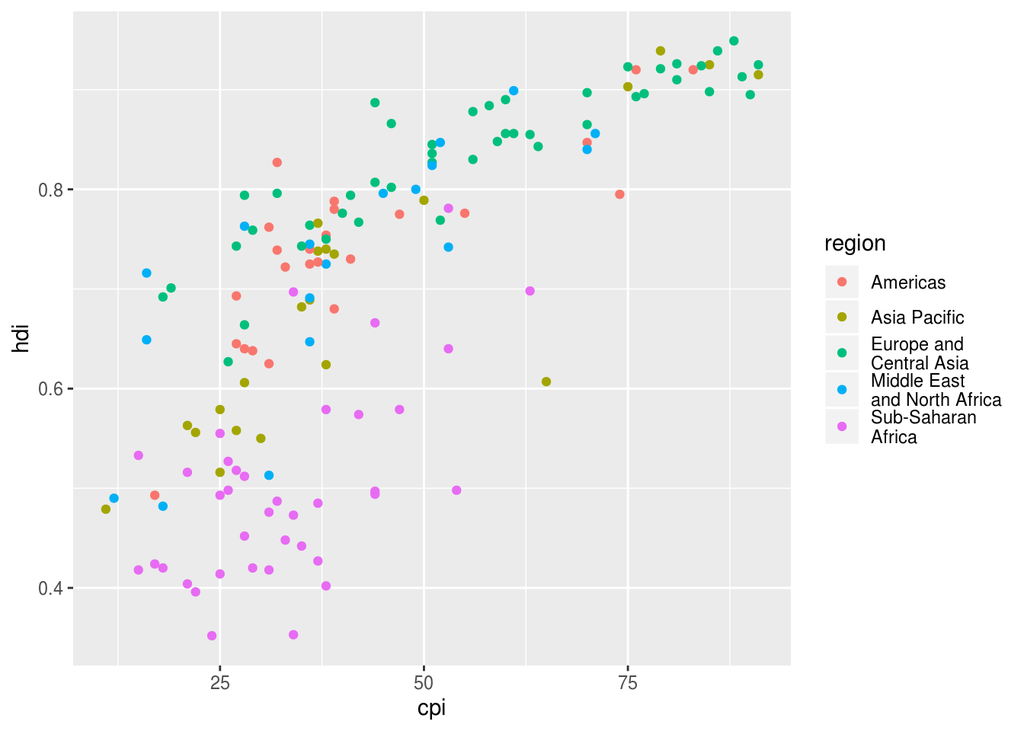

```r
# simple ggplot of geom_point()
ggplot(corrupt, aes(x = cpi, y = hdi, color = region)) +
  geom_point()
```

### Question 8

- What are three problems with this graph (or ways you could improve this graph)?
1. HDI and CPI are not defined in what they are
2. No title
3. Perhaps include some callouts on points to identify well-known countries

Now, let’s modify our points.

First, let’s reshape each point.

### Code 7

Within your `geom_point` function, add in the following fixed parameters:

1. **size** to 2.5
2. **alpha** to 0.5
3. **shape** to 21

hint: since these three values are fixed, should the be inside or outside the aesthetics (`aes()`) function?

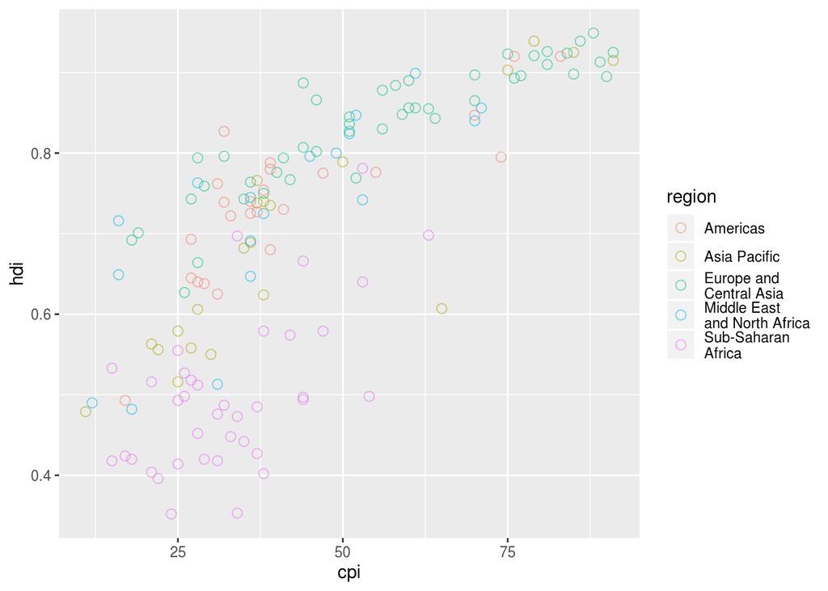

```r
# modify the geom_point parameters
ggplot(corrupt, aes(x = cpi, y = hdi, color = region)) +
  geom_point(size = 2.5, alpha = 0.5, shape = 21)
```

### Question 9

- What does the `alpha` parameter do?

This changes the darkness of the points. A smaller alpha means a lighter point.

The plot is too transparent. The issue is the parameter `color` encodes the color of the border, not the color of the point.

That’s where we’ll need the `fill` parameter.

### Code 8

Put these two parameters explicitly in the `aes()` function of the `geom_point()`:

1. `color = region`
2. `fill = region`

Also, make sure to remove any mention of color or fill in the `aes()` of your main `ggplot()` function.

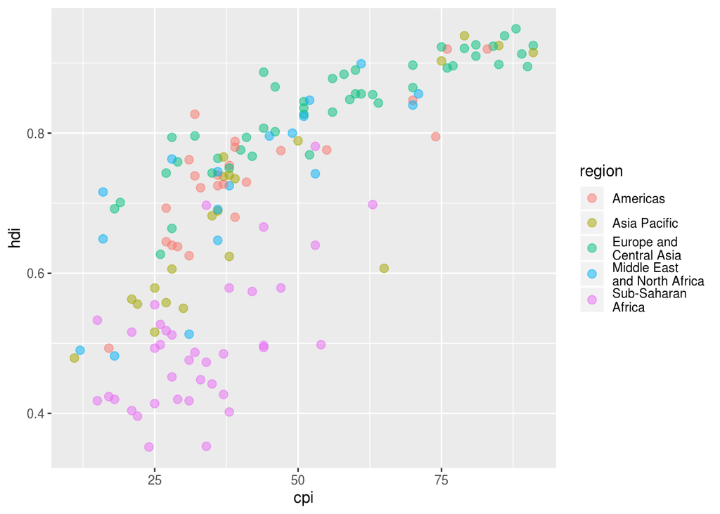

```r
# modify the ggplot function
ggplot(corrupt, aes(x = cpi, y = hdi)) +
  geom_point(aes(color = region, fill = region), size = 2.5, alpha = 0.5, shape = 21)
```

Last, let’s temporarily save this graph as an object `g`. We can use the same `<-` (gets arrow) assignment operator. This will enable us to view the object or we can use it to build additional layers (Task 2).

### Code 9

Assign the ggplot from the previous part to `g` and then run `g` on its within the chunk.

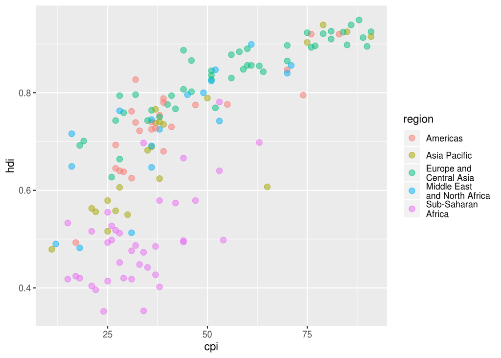

```r
# assign plot to g
g <- ggplot(corrupt, aes(x = cpi, y = hdi)) +
  geom_point(aes(color = region, fill = region), size = 2.5, alpha = 0.5, shape = 21)

# simply put "g" to view the plot
g
```

## Part 2: Re-designing

In this part, you’ll add additional layers to our plot to re-design it.

This part is much more complicated, so your job will be easier:

1. Remove the `eval=F` parameter from each chunk to run each chunk when `knit` your output.
2. Answer questions on interpreting what’s going on.

For this, we’ll use the same `g` object you created in the last chunk and slowly add more layers to the plot.

Before starting, we’ll need two packages: `cowplot` and `colorspace`. You can install `colorspace` from CRAN (remember how to?). For `cowlplot`, you need the most recent version which is on GitHub.

Installing packages from GitHub is relatively straight-forward. But you need an additional package: `devtools`. You can then run the line below to install it.

### Code 10

Install `cowplot` and `colorspace` and call these libraries. Also, remove the `eval=F` parameter from each chunk to run each chunk when `knit` your output. (hint: you can do this for all parts via Edit > Replace and Find or CTRL + F)

```r
# devtools::install_github("wilkelab/cowplot") # do you have devtools installed?

library(cowplot) # for theme_minimal_hgrid()
library(colorspace) # for darken()
```

### Question 10

- What does the parameters `warning=F` and `message=F` do within the code chunk?

These suppress warnings and messages in the code chunk.

#### Import unique theme and font size

Modifying themes are very common in ggplot. There are a range of packages to change plot themes like [`ggtheme`](https://ggplot2.tidyverse.org/reference/ggtheme.html).

For this plot, we’ll use a theme built within the `cowplot` package that is a minimal background with a horizontal grid.

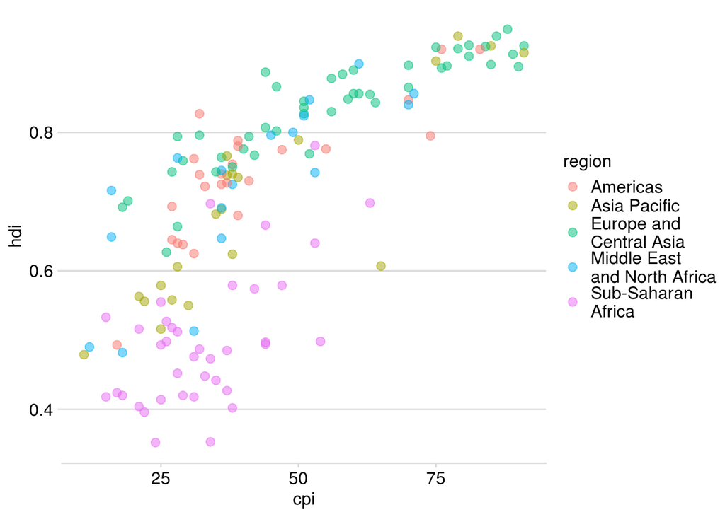

```r
g <- g +
  cowplot::theme_minimal_hgrid(12, rel_small = 1) # font size 12 pt throughout

g
```

### Question 11

- What does the `cowplot::` pre-fix for `theme_minimal_hgrid()` mean? When would it be necessary?

This means use the function from the cowplot package. It is necessary when there are multiple packages with theme_minimal_hgrid().

#### Modify color scheme

Next, let’s modify the color scheme. Colors can be represented by [hex colors](https://www.color-hex.com/).

Sometimes, color palettes come in as R packages (e.g., [`RColorBrewer`](https://cran.r-project.org/web/packages/RColorBrewer/index.html)). However, for this plot we’ll manuall load up the colors.

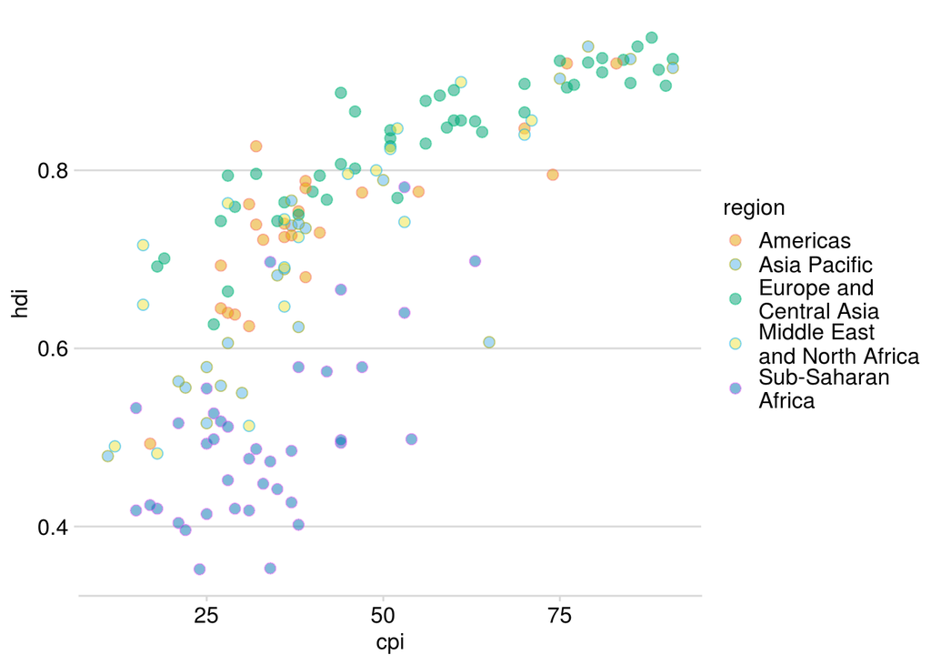

```r
# Okabe Ito colors
region_cols <- c("#E69F00", "#56B4E9", "#009E73", "#F0E442", "#0072B2", "#999999")

g <- g +
  scale_fill_manual(
    values = region_cols
  )

g
```

#### Darken colors by 30%

We can also darken the color scheme automatically through `colorspace`’s `darken()` function.

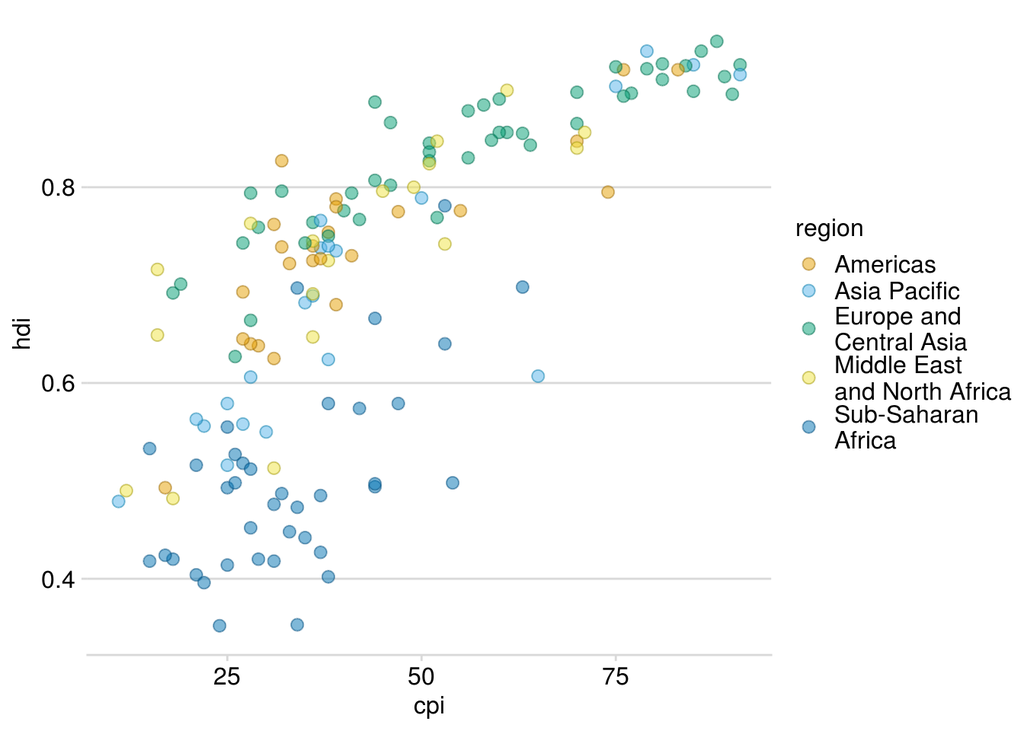

```r
g <- g +
  scale_color_manual(
    values = colorspace::darken(region_cols, 0.3)
  )

g
```

#### Add smoothing line.

Let’s now overlay a basic regression, using the `geom_smooth()` function.

For this, we’ll make the function a log transformation of x.

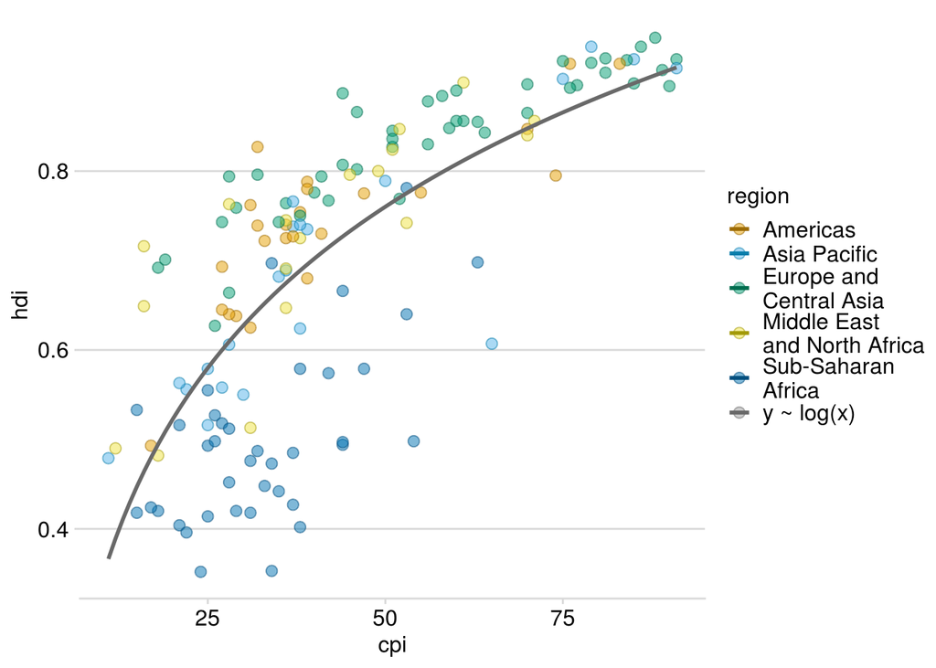

```r
g <- g +
  geom_smooth(
    aes(color = "y ~ log(x)", fill = "y ~ log(x)"),
    method = 'lm', formula = y~log(x), se = FALSE, fullrange = TRUE
  )

g
```

### Question 12

- What would be the difference in the plot if our smoothed function was `y~x` instead of `y~log(x)`?

The line would be straight instead of curved.

#### Set x and y scales, move legend on top.

Let’s now modify our scales, add scale labels, and modify the legend.

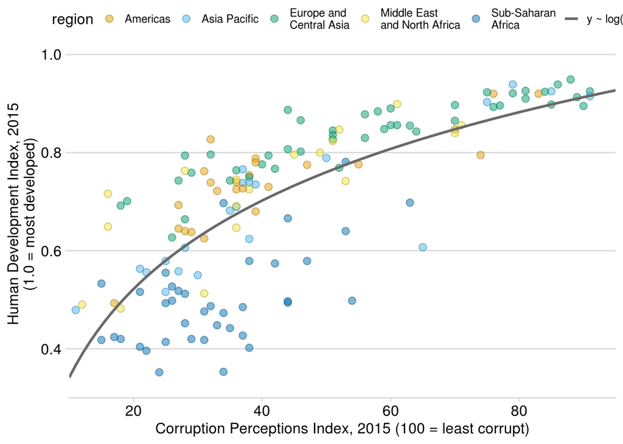

```r
g <- g +
  scale_x_continuous(
    name = "Corruption Perceptions Index, 2015 (100 = least corrupt)",
    limits = c(10, 95),
    breaks = c(20, 40, 60, 80, 100),
    expand = c(0, 0)
  ) +
  scale_y_continuous(
    name = "Human Development Index, 2015\n(1.0 = most developed)",
    limits = c(0.3, 1.05),
    breaks = c(0.2, 0.4, 0.6, 0.8, 1.0),
    expand = c(0, 0)
  ) +
  theme(
    legend.position = "top",
    legend.justification = "right",
    legend.text = element_text(size = 9),
    legend.box.spacing = unit(0, "pt")
  ) +
  guides(
    fill = guide_legend(
      nrow = 1,
      override.aes = list(
        linetype = c(rep(0, 5), 1),
        shape = c(rep(21, 5), NA)
      )
    )
  )

g
```

#### Highlight select countries.

Last, let’s add labels to highlight the countries.

We can use the `ggrepel` package that includes the `geom_text_repel()` function that makes sure not to overlap labels.

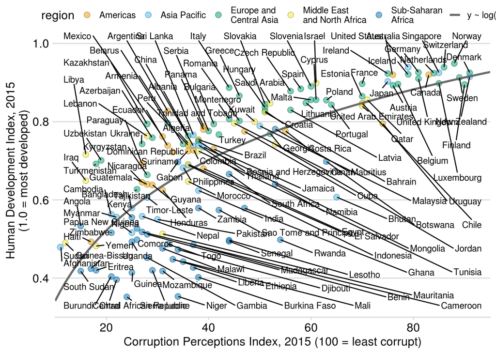

```r
library(ggrepel)

# don't assign this to g
# if you do, then simply recreate g by running the "Run All Chunks Above" button
g +
  geom_text_repel(
    aes(label = country),
    color = "black",
    size = 9/.pt, # font size 9 pt
    point.padding = 0.1,
    box.padding = .6,
    min.segment.length = 0,
    seed = 7654
  )
```

Obviously, this is too busy. We have too many labels.

Let’s instead create a vector of countries we want to plot. We can the add in a new column that has the country name only if we want to plot it and nothing (“”) otherwise.

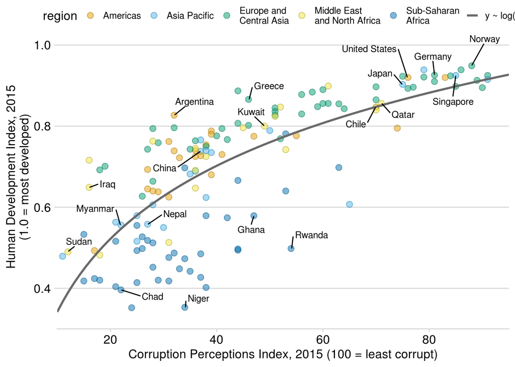

```r
country_highlight <- c("Germany", "Norway", "United States", "Greece", "Singapore", "Rwanda", "Russia", "Venezuela", "Sudan", "Iraq", "Ghana", "Niger", "Chad", "Kuwait", "Qatar", "Myanmar", "Nepal", "Chile", "Argentina", "Japan", "China")

corrupt <- corrupt %>%
  mutate(
    label = if_else(country %in% country_highlight, as.character(country), "")
  )

# wow: %+%
# https://stackoverflow.com/questions/29336964/changing-the-dataset-of-a-ggplot-object

g <- g %+%
  corrupt +
  geom_text_repel(
    aes(label = label),
    color = "black",
    size = 9/.pt, # font size 9 pt
    point.padding = 0.1,
    box.padding = .6,
    min.segment.length = 0,
    seed = 7654
  )

g
```

### Question 13

- What do you think the `%+%` operator does (see the StackOverflow link)? Why is it necessary in this context?

This changes the the dataset used by an already created ggplot. It is needed because we changed the corrupt variable after creating the ggplot g.

#### Save as a pdf file

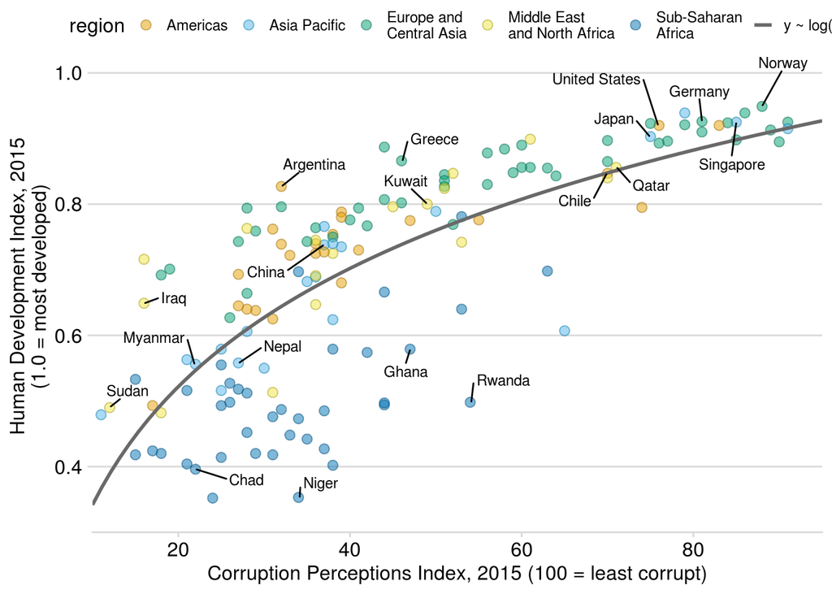

```r
g + ggsave("corrupt.pdf", width = 8, height = 5)
```

You now have a pdf saved as this plot. By setting the width and height, it’ll make your life so much easier if you need to reproduce this plot (very likely).

### Question 14

- From this graph, how would you interpret countries that are above the regression line versus countries that are below?

These countries are more developed then the average country at that corruption index.

### Question 15

- What role does region have in the relationship between Corruption (Perception) and HDI?

Regions are mostly clustered together with sub-saharan countries below the regression line and European and central Asian countires above the line.